# GET00203 - Estatística Computacional 1

Aula 08 - Método da Máxima Verossimilhança e Avaliação de Funções de Verossimilhança

[Rafael Erbisti](https://sites.google.com/site/rerbisti)

### Função de Verossimilhança

#### Motivação

Suponha que uma urna contém um certo número de bolas pretas e brancas, e que sabemos que a proporção é de 3 para 1, porém não sabemos se as pretas ou as brancas são mais numerosas. Como estimar a proporção de bolas pretas e brancas na urna?

Se denotamos por $p$ a probabilidade de sortear uma bola preta dessa urna, então necessariamente $p = \frac{1}{4}$ ou $p = \frac{3}{4}$. Mas como decidir entre esses dois valores?

Para tentar responder a essa pergunta, sorteamos uma amostra aleatória de $n$ bolas desta urna. De fato, supondo a variável aleatória $X$ que conta o número de bolas pretas na amostra, temos que $X \sim \text{Bin}(n, p)$ para qualquer que seja o verdadeiro valor de $p$, e

$$p_X(x) = \begin{cases}
\binom{n}{x} p^x (1 - p)^{n - x}, & \text{para } x = 0, 1, \dots, n
\\
0, & \text{caso contrário}.
\end{cases}$$

Suponha o caso em que $n = 3$. Neste caso, temos:

$$\begin{array}{c|cccc}
x & 0 & 1 & 2 & 3 \\
\hline
p = \frac{1}{4} & \frac{27}{64} & \frac{27}{64} &
\frac{9}{64} & \frac{1}{64} \\
p = \frac{3}{4} & \frac{1}{64} & \frac{9}{64} &
\frac{27}{64} & \frac{27}{64} \\
\end{array}$$

Suponha que observamos $x = 1$ neste experimento. Neste caso, o que parece mais razoável, $p = \frac{1}{4}$ ou $p = \frac{3}{4}$? E se $x = 3$?

Se tivéssemos que escolher uma regra para determinar a estimativa mais razoável neste caso, esta seria da forma

$$\hat{p} = \begin{cases}
\frac{1}{4}, & \text{se } x = 0, 1 \\
\frac{3}{4}, & \text{se } x = 2, 3 \\
\end{cases}$$

**Definição**

Seja $X = (X_1, \dots, X_n)'$ um vetor aleatório cuja distribuição é descrita por um parâmetro $\theta \in \Theta$. Supondo que $X$ tenha função de probabilidade/densidade de probabilidade conjunta $f(x)$, dada uma realização de $x = (x_1, \dots, x_n)'$ de $X$, definimos a (função de) verossimilhança de $\theta$, denotada por $l(\theta; x)$, como sendo a função de probabilidade/densidade de probabilidade conjunta de $X$ avaliada em $x$ e vista como função de $\theta$.

**Intuição**

A função de verossimilhança indica o quão plausível/verossímil é cada valor de $\theta$, dada a observação de $X = x$.

#### Exemplo

Supondo

$$X \sim \text{Binomial}(2, \theta) \Rightarrow p_X(x) = \begin{cases}
\binom{2}{x} \theta^x (1 - \theta)^{2 - x}, & x = 0, 1, 2 \\
0, & \text{caso contrário}.
\end{cases}$$

Agora, note que a função de verossimilhança neste caso é dada por

$$l(\theta; x) = \binom{2}{x} \theta^x (1 - \theta)^{2 - x}, \quad \theta
\in (0, 1).$$

Em particular,

1. $x = 0 \Rightarrow l(\theta; x = 0) = (1 - \theta)^2$
2. $x = 1 \Rightarrow l(\theta; x = 1) = 2 \theta (1 - \theta)$
3. $x = 2 \Rightarrow l(\theta; x = 2) = \theta^2$

Para visualizar as funções de verossimilhança $l(\theta; x)$ para $x = 0$, $x = 1$ e $x = 2$, podemos criar o seguinte gráfico:

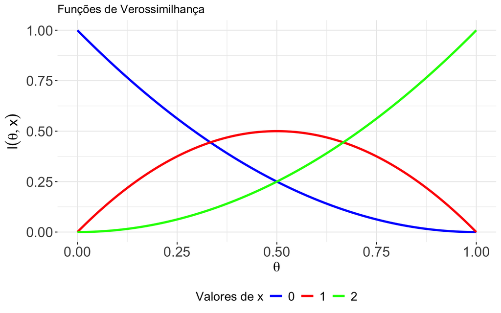

```r
# Carregar o pacote ggplot2
library(ggplot2)

# Define valores de theta
theta = seq(0, 1, length.out = 100)

# Calcula as funções de verossimilhança para diferentes valores de x e organiza em um data frame
data = data.frame(
  theta = rep(theta, 3),
  likelihood = c((1 - theta)^2, 2 * theta * (1 - theta), theta^2),
  x = factor(rep(c(0, 1, 2), each = length(theta))))

# Criando o gráfico com ggplot2
ggplot(data, aes(x = theta, y = likelihood, color = x)) +
  geom_line(size = 1.2) +
  labs(title = "Funções de Verossimilhança",
    x = expression(theta),
    y = expression(l(theta, x)),
    color = "Valores de x") +
  scale_color_manual(values = c("blue", "red", "green")) +
  theme_bw() +
  theme(legend.position = "bottom",
        legend.text = element_text(size = 14),
        legend.title = element_text(size = 14),
        axis.text.x = element_text(size = 16),
        axis.title.x = element_text(size = 16),
        axis.text.y = element_text(size = 16),
        axis.title.y = element_text(size = 16),
        panel.border = element_blank())
```

**Observações:**

1. O $l$ da notação vem do inglês *likelihood* (verossimilhança).
2. **Cuidado!**
   - $f(x)$ é função de $x$ e temos sempre $\int_{\mathbb{R}} f(x) \, dx = 1$.
   - $l(\theta; x)$ é função de $\theta$ e, em geral, $\int_{\Theta} l(\theta; x) \, d\theta \neq 1$.

No exemplo,

$$\int_0^1 l(\theta; x) \, d\theta = \int_0^1 \binom{2}{x} \theta^x (1 -
\theta)^{2 - x} \, d\theta = \binom{2}{x} \frac{\Gamma(x + 1) \Gamma(3 -
x)}{\Gamma(x + 1 + 3 - x)} = \binom{2}{x} \frac{x!(2 - x)!}{3!} =
\frac{1}{3}.$$

#### Exemplo

Sejam $X_i \sim N(\mu,4)$, $i=1,\ldots,n$, a função de verossimilhança $l(\mu; \textbf{x})$ é dada por:

$$l(\mu; \textbf{x}) = \prod_{i=1}^n f(x_i) = \prod_{i=1}^n
\frac{1}{\sqrt{8 \pi}} \exp \left( -\frac{(x_i - \mu)^2}{8} \right).$$

Podemos simplificar essa expressão para:

$$l(\mu; \textbf{x}) = (8 \pi)^{-\frac{n}{2}} \exp \left( -\frac{1}{8}
\sum_{i=1}^n (x_i - \mu)^2 \right).$$

Expandindo a soma, obtemos:

$$l(\mu; \textbf{x}) = (8 \pi)^{-\frac{n}{2}} \exp \left( -\frac{1}{8}
\left( \sum_{i=1}^n x_i^2 - 2 \mu \sum_{i=1}^n x_i + n \mu^2 \right)
\right).$$

Para visualizar a função de verossimilhança $l(\mu; \textbf{x})$ em função de $\mu$, considere o código abaixo:

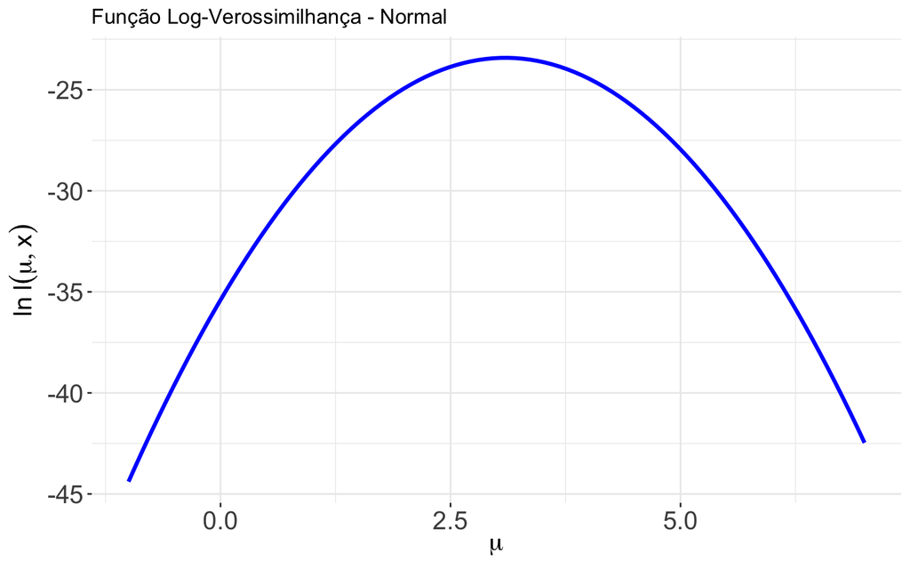

```r
# Parâmetros
n = 10  # tamanho da amostra
x = rnorm(n, mean = 3, sd = 2)  # gerar uma amostra com média 3 e variância 4

# Valores de mu para o gráfico
mu = seq(-1, 7, length.out = 100)

# Calcular a verossimilhança
log_likelihood = sapply(mu, function(m) {
  sum(dnorm(x, mean = m, sd = 2, log = TRUE))})

# Criar um data frame para o ggplot
data = data.frame(mu = mu, log_likelihood = log_likelihood)

# Plotar a função de log-verossimilhança
ggplot(data, aes(x = mu, y = log_likelihood)) +
  geom_line(color = "blue", size = 1.2) +
  labs( title = "Função Log-Verossimilhança - Normal",
    x = expression(mu),
    y = expression(ln ~ l(mu, x))) +
  theme_bw() +
  theme(axis.text.x = element_text(size = 16),
        axis.title.x = element_text(size = 16),
        axis.text.y = element_text(size = 16),
        axis.title.y = element_text(size = 16),
        panel.border = element_blank())
```

#### Exemplo

Suponha que $X_i \sim Poisson(\lambda)$, $i=1,\ldots,n$. Portanto, a função de verossimilhança $l(\lambda; \textbf{x})$ é dada por:

$$l(\lambda; \textbf{x}) = \prod_{i=1}^n f(x_i) = \prod_{i=1}^n
\frac{\lambda^{x_i} e^{-\lambda}}{x_i!}.$$

Podemos simplificar essa expressão para:

$$l(\lambda; \textbf{x}) = \frac{\lambda^{\sum_{i=1}^n x_i} e^{-n
\lambda}}{\prod_{i=1}^n x_i!}.$$

Na escala do logaritmo, temos:

$$\ln l(\lambda; \textbf{x}) = \sum_{i=1}^n \ln f(x_i) = \sum_{i=1}^n x_i
\ln \lambda - n \lambda - \sum_{i=1}^n \ln x_i!.$$

Para visualizar a função de verossimilhança $l(\lambda; \textbf{x})$ em função de $\lambda$, considere o código abaixo:

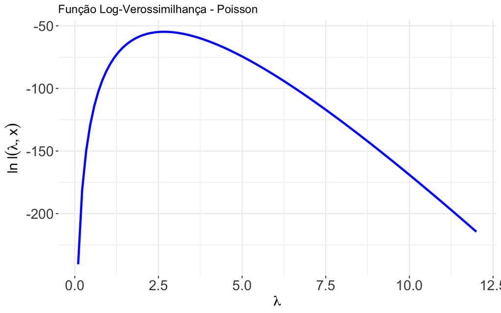

```r
# Parâmetros
n = 30  # tamanho da amostra
x = rpois(n, lambda = 3)  # gerar uma amostra com lambda = 3

# Valores de lambda para o gráfico
lambda = seq(0.1, 12, length.out = 100)

# Calcular a log-verossimilhança
log_likelihood = sapply(lambda, function(l) {
  sum(dpois(x, lambda = l, log = TRUE))})

# Criar um data frame para o ggplot
data = data.frame(lambda = lambda, log_likelihood = log_likelihood)

# Plotar a função de log-verossimilhança
ggplot(data, aes(x = lambda, y = log_likelihood)) +
  geom_line(color = "blue", size = 1.2) +
  labs(title = "Função Log-Verossimilhança - Poisson",
    x = expression(lambda),
    y = expression(ln ~ l(lambda, x))) +
  theme_bw() +
  theme(axis.text.x = element_text(size = 16),
        axis.title.x = element_text(size = 16),
        axis.text.y = element_text(size = 16),
        axis.title.y = element_text(size = 16),
        panel.border = element_blank())
```

#### Exemplo

De maneira análoga, para $X_i \sim Beta(\alpha,2)$, com $i=1,\ldots,n$ tem-se que a função de verossimilhança $l(\alpha; \textbf{x})$ é dada por:

$$l(\alpha; \textbf{x}) = \prod_{i=1}^n f(x_i) = \prod_{i=1}^n
\frac{x_i^{\alpha - 1} (1 - x_i)^{2 - 1}}{B(\alpha, 2)},$$

onde $B(\alpha, 2)$ é a função Beta definida como:

$$B(\alpha, 2) = \int_0^1 t^{\alpha - 1} (1 - t)^{2 - 1} \, dt =
\frac{\Gamma(\alpha) \Gamma(2)}{\Gamma(\alpha + 2)}.$$

Portanto, a função de verossimilhança pode ser escrita como:

$$l(\alpha; \textbf{x}) = \frac{1}{B(\alpha, 2)} \prod_{i=1}^n x_i^{\alpha
- 1} (1 - x_i).$$

Para visualizar a função de verossimilhança $l(\alpha; \textbf{x})$ em função de $\alpha$, considere o código abaixo:

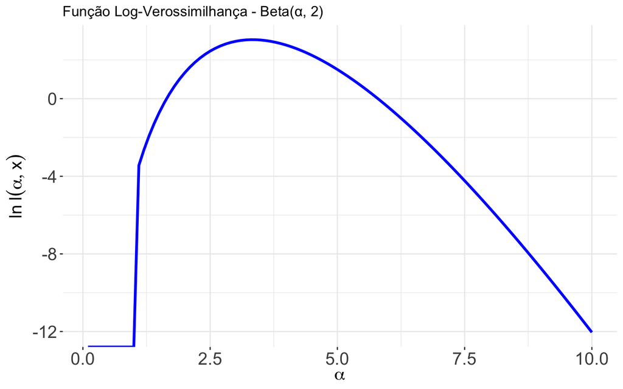

```r
# Parâmetros
n = 10  # tamanho da amostra
x = rbeta(n, shape1 = 3, shape2 = 2)  # gerar uma amostra com beta(3, 2)

# Valores de alpha para o gráfico
alpha = seq(0.1, 10, length.out = 100)

# Calcular a log-verossimilhança
log_likelihood = sapply(alpha, function(a) {
  # Verificar se alpha é maior que 1 para evitar problemas com log
  if (a <= 1) return(-Inf)  # Retorna -Inf para alpha <= 1
  sum((a - 1) * log(x) + (1) * log(1 - x)) - n * (lgamma(a) + lgamma(2) - lgamma(a + 2))})

# Criar um data frame para o ggplot
data = data.frame(alpha = alpha, log_likelihood = log_likelihood)

# Plotar a função de log-verossimilhança
ggplot(data, aes(x = alpha, y = log_likelihood)) +
  geom_line(color = "blue", size = 1.2) +
  labs(title = "Função Log-Verossimilhança - Beta(α, 2)",
    x = expression(alpha),
    y = expression(ln ~ l(alpha, x))) +
  theme_bw() +
  theme(axis.text.x = element_text(size = 16),
        axis.title.x = element_text(size = 16),
        axis.text.y = element_text(size = 16),
        axis.title.y = element_text(size = 16),
        panel.border = element_blank())
```

> **Desafio:** Suponha que $X_i \sim N(10,\sigma^2)$, com $i =1,\ldots, 25$. Defina a função de verossimilhança $l(\sigma^2;\textbf{x})$ e a função log-verossimilhança. Gere as observações $x_i$ da $N(10, 25)$. Faça um gráfico da curva da função de verossimilhança e outro gráfico com a curva da função log-verossimilhança. Interprete os resultados avaliando o valor que maximiza ambas as funções.